# Part II - Effects of MonthlyLoanPayment,EmploymentStatus, and ProsperScore on LoanStatus

## By Metsebiya Akililu Bizuneh

## Investigation Overview

> In this investigation, I wanted to look at the behaviour of around 11 variables that could be used to predict loan status of borrowers . The main focus was on the Employment Status, MonthlyLoanPayment and PaymentScore.

## Dataset Overview

> Prosper is the first peer-to-peer lending market place in America. This document is used to visualize a loan data from Prosper. It contains 113,937 loans with 81 variables on each loan, including loan amount, borrower rate (or interest rate),current loan status, borrower income, and many others.

## Distribution of LoanStatus

LoanStatus is a categorical variable showing the status of borrowers' loan payment. There are about 10 stages of Loan Status. As it is shown in the visualization, most borrowers are on the stage of currently paying their loans.

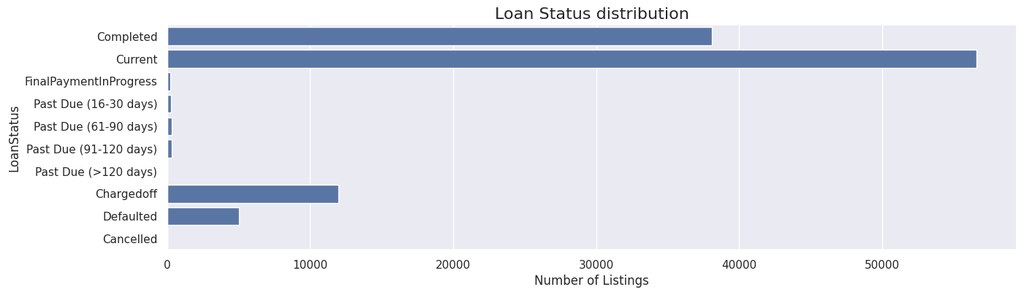

## Distribution of Term Distribution

The term variable has 3 values to describe payment duration based on month. It has lower value of 12 and upper range of 60. Based on the visualization, most borrowers pay thier loans within 36 months.

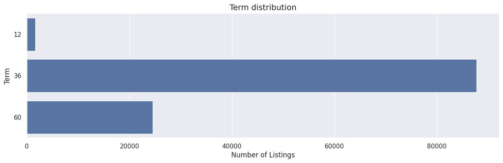

## Distribution of EmploymentStatus Distribution

EmploymentStatus contains categorical value of borrower's employment status.There are different status starting from employed to retired one. Most of the borrowers are employed.

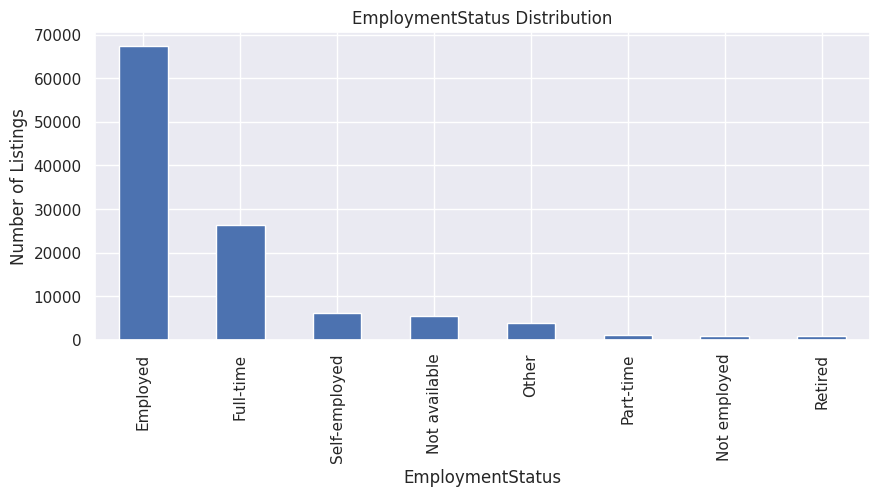

## Relationship between MonthlyLoanPayment and LoanStatus

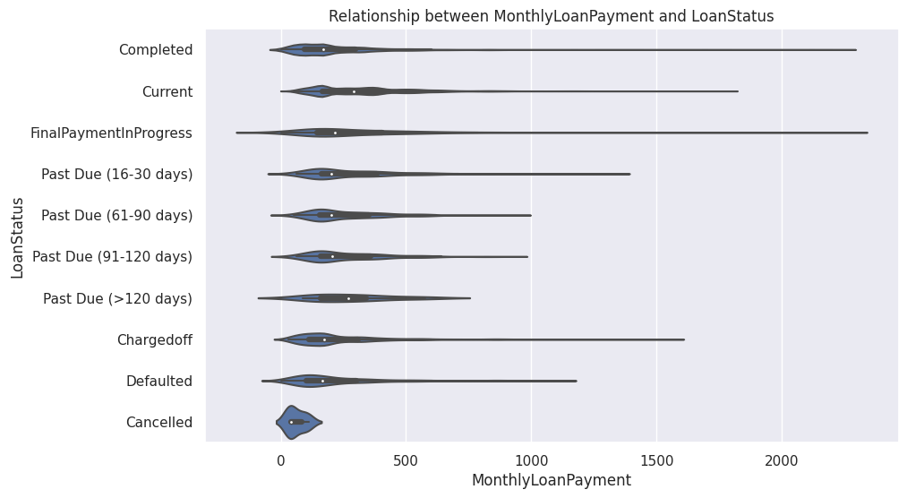

## Relationship among the variables LoanStatus,EmloymentStatus, MonthlyLoanPayment and ProsperScore

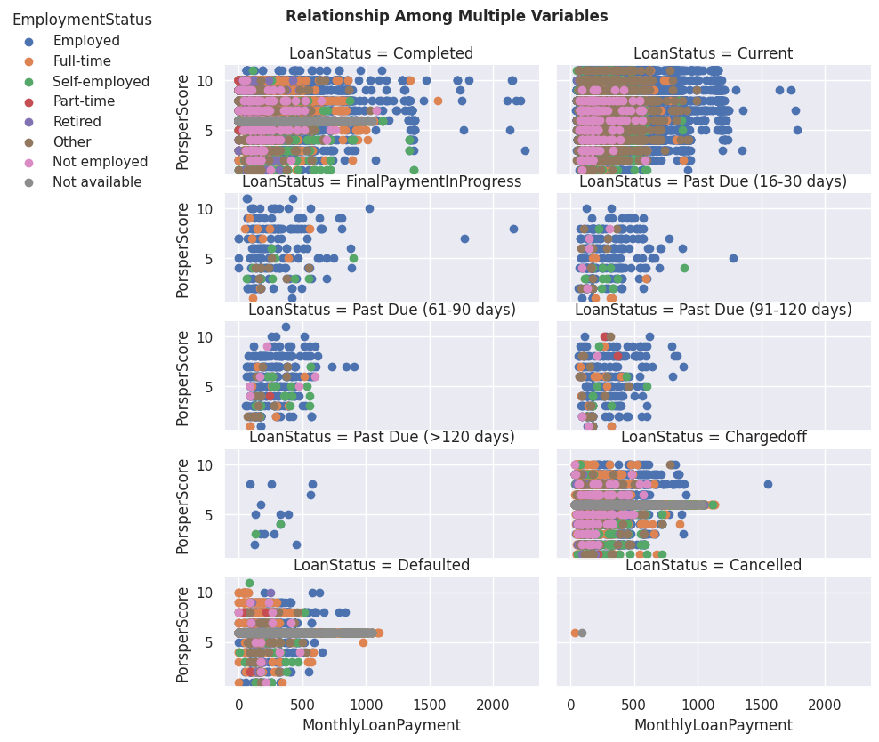

## Relationship among the variables LoanStatus,Term, MonthlyLoanPayment and ProsperScore

From this visualization part, It is clearly seen, that borrowers who are currently paying thier monthly loan payment prefer 60 months and 36 months payment term at all levels of prosper score range. On the other hand, we find borrowers with completed loan status choosing 12 month term to perform their monthly loan payment.

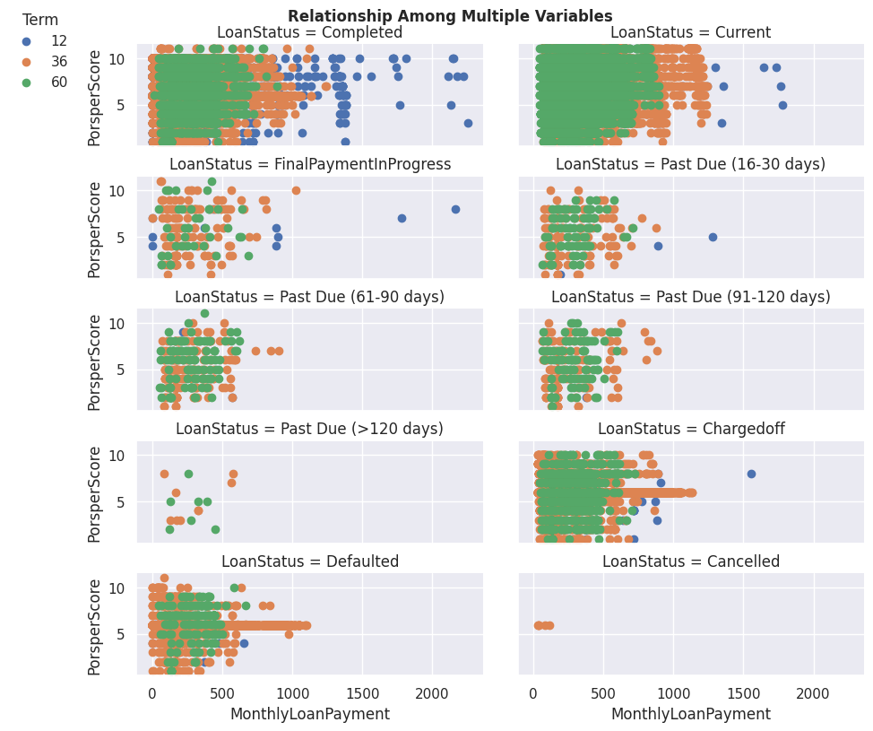